# Project: Investigate a Dataset - Gapminder

- Introduction
- Data Wrangling
- Exploratory Data Analysis
- Conclusions

## Introduction

### Dataset Description

> **About Gapminder**: Gapminder has collected a lot of information about how people live their lives in different countries, tracked across the years, and on a number of different indicators.

For this project plan, CO2 emission per person will be collected together with GDP per capita (inflation-adjusted), broadband subscribers per 100 people, freedom index, industry percent in GDP, agricultural percent in GDP. Each indicator is stored in a separate excel spreadsheet downloaded on 23rd March 2022. These indicators are merged together in one full dataset.

The variable descriptions below are extracted from the source data.

> CO2 emission per person indicates carbon dioxide emission from burning fossil fuels (tonnes per person) (https://cdiac.ess-dive.lbl.gov/).

> broadband subscribers per 100 people refers to fixed subscriptions to high-speed access to the public Internet (a TCP/IP connection), at downstream speeds equal to, or greater than, 256 kbit/s. This includes cable modem, DSL, fiber-to-the-home/building, other fixed (wired)-broadband subscriptions, satellite broadband and terrestrial fixed wireless broadband. This total is measured irrespective of the method of payment. It excludes subscriptions that have access to data communications (including the Internet) via mobile-cellular networks. It should include fixed WiMAX and any other fixed wireless technologies. It includes both residential subscriptions and subscriptions for organizations (https://data.worldbank.org/indicator/IT.NET.BBND.P2).

> GDP per capita (inflation-adjusted) is gross domestic product divided by midyear population. GDP is the sum of gross value added by all resident producers in the economy plus any product taxes and minus any subsidies not included in the value of the products. It is calculated without making deductions for depreciation of fabricated assets or for depletion and degradation of natural resources. Data are in constant 2015 U.S. dollars https://data.worldbank.org/indicator/NY.GDP.PCAP.KD).

> Political rights index / Freedom index (FI) is the average of political rights and civil liberties ratings and is used to determine countries' freedom statuses. It's range on a scale of 1 (most free) to 7 ( least free) (http://gapm.io/dfreedom_fh).

> Industry (including construction), value added (% of GDP) Industry (including construction) corresponds to ISIC divisions 05-43 and includes manufacturing (ISIC divisions 10-33). It comprises value added in mining, manufacturing (also reported as a separate subgroup), construction, electricity, water, and gas. Value added is the net output of a sector after adding up all outputs and subtracting intermediate inputs. It is calculated without making deductions for depreciation of fabricated assets or depletion and degradation of natural resources. The origin of value added is determined by the International Standard Industrial Classification (ISIC), revision 4. Note: For VAB countries, gross value added at factor cost is used as the denominator (https://data.worldbank.org/indicator/NV.IND.TOTL.ZS).

> Agriculture, forestry, and fishing, value added (% of GDP) Agriculture, forestry, and fishing corresponds to ISIC divisions 1-3 and includes forestry, hunting, and fishing, as well as cultivation of crops and livestock production. Value added is the net output of a sector after adding up all outputs and subtracting intermediate inputs. It is calculated without making deductions for depreciation of fabricated assets or depletion and degradation of natural resources. The origin of value added is determined by the International Standard Industrial Classification (ISIC), revision 4. Note: For VAB countries, gross value added at factor cost is used as the denominator (https://data.worldbank.org/indicator/NV.AGR.TOTL.ZS).

> In addition, reference for countries and the continents associated with them are downloaded from https://github.com/dbouquin/IS_608/blob/master/NanosatDB_munging/Countries-Continents.csv

### Question(s) for Analysis

> **Question 1**: Is the average CO2 per person going up or down between 1998 and 2017? Are there any differences among the continents?

> **Question 2**: Are there any possible correlations found between the CO2 emission per person and other indexes including the GDP per capita, number of broadband subscribers per 100 people, freedom index, percentage of industry contribution to the GDP, and percentage of agriculture contribution to the GDP

```python
# import packages to be used in the project


import pandas as pd

import numpy as np

import matplotlib.pyplot as plt
%matplotlib inline

import seaborn as sn

#read the excel files
co2_per_person = pd.read_excel('co2_emissions_tonnes_per_person.xlsx')
BroadBandSubscriber_per_100ppl = pd.read_excel('broadband_subscribers.xlsx')
gdp_per_Capita = pd.read_excel('gdppercapita_us_inflation_adjusted.xlsx')
freedom_index = pd.read_excel('polrights_fh.xlsx')
industry_GDPpercent = pd.read_excel('industry_percent_of_gdp.xlsx')
agriculture_GDPpercent = pd.read_excel('agriculture_percent_of_gdp.xlsx')
```

```python
#Restructure the dataset with year as one column in all component datasets
co2_per_person = pd.melt(co2_per_person, id_vars=['country'], value_vars=np.arange(1800,2018,1),var_name='year', value_name='co2_per_person').sort_values(['country','year'])

BroadBandSubscriber_per_100ppl = pd.melt(BroadBandSubscriber_per_100ppl, id_vars=['country'], value_vars=np.arange(1998,2020,1),var_name='year', value_name='BroadbandSubscriber_Per100ppl').sort_values(['country','year'])

gdp_per_Capita = pd.melt(gdp_per_Capita, id_vars=['country'], value_vars=np.arange(1960,2020,1),var_name='year', value_name='gdpPerCapita').sort_values(['country','year'])
freedom_index = pd.melt(freedom_index, id_vars=['country'], value_vars=np.arange(1972,2020,1),var_name='year', value_name='freedom_index').sort_values(['country','year'])
industry_GDPpercent = pd.melt(industry_GDPpercent, id_vars=['country'], value_vars=np.arange(1960,2020,1),var_name='year', value_name='industry_GDPpercent').sort_values(['country','year'])

agriculture_GDPpercent= pd.melt(agriculture_GDPpercent, id_vars=['country'], value_vars=np.arange(1960,2020,1),var_name='year', value_name='agriculture_GDPpercent').sort_values(['country','year'])
```

```python
#Merge all the datasets together in one big dataset full_data
full_data = pd.merge(co2_per_person,BroadBandSubscriber_per_100ppl, on = ["country","year"])
full_data = pd.merge(full_data,gdp_per_Capita, on = ["country","year"])
full_data = pd.merge(full_data,freedom_index, on = ["country","year"])
full_data = pd.merge(full_data,industry_GDPpercent, on = ["country","year"])
full_data = pd.merge(full_data,agriculture_GDPpercent, on = ["country","year"])
```

```python
#Check the first few rows to see how the data looks
full_data.head()
```

|  | country | year | co2_per_person | BroadbandSubscriber_Per100ppl | gdpPerCapita | freedom_index | industry_GDPpercent | agriculture_GDPpercent |
| --- | --- | --- | --- | --- | --- | --- | --- | --- |
| 0 | Afghanistan | 1998 | 0.0522 | NaN | NaN | 7.0 | NaN | NaN |
| 1 | Afghanistan | 1999 | 0.0402 | NaN | NaN | 7.0 | NaN | NaN |
| 2 | Afghanistan | 2000 | 0.037 | NaN | NaN | 7.0 | NaN | NaN |
| 3 | Afghanistan | 2001 | 0.0376 | NaN | NaN | 7.0 | NaN | NaN |
| 4 | Afghanistan | 2002 | 0.0471 | NaN | 333 | 6.0 | 23.8 | 38.6 |

```python
#The years that we get from the data
full_data['year'].unique()
```

```
array([1998, 1999, 2000, 2001, 2002, 2003, 2004, 2005, 2006, 2007, 2008,
       2009, 2010, 2011, 2012, 2013, 2014, 2015, 2016, 2017], dtype=object)
```

## Data Wrangling

> **Tip**: In this section of the report, you will load in the data, check for cleanliness, and then trim and clean your dataset for analysis. Make sure that you **document your data cleaning steps in mark-down cells precisely and justify your cleaning decisions.**

### General Properties

> **First observation**: There are quite a lot of null values in many columns. We will need to drop these null values first before the exploratory analysis

```python
# Load your data and print out a few lines. Perform operations to inspect data
#   types and look for instances of missing or possibly errant data.
full_data.info()
```

```
<class 'pandas.core.frame.DataFrame'>
Int64Index: 3680 entries, 0 to 3679
Data columns (total 8 columns):
country                          3680 non-null object
year                             3680 non-null object
co2_per_person                   3676 non-null object
BroadbandSubscriber_Per100ppl    2715 non-null object
gdpPerCapita                     3597 non-null object
freedom_index                    3650 non-null float64
industry_GDPpercent              3470 non-null float64
agriculture_GDPpercent           3494 non-null float64
dtypes: float64(3), object(5)
memory usage: 258.8+ KB
```

```python
#it seems that we are missing quite a lot of countries and years for Broadband subscriber per 100 people

full_data[full_data['BroadbandSubscriber_Per100ppl'].isnull()].groupby('country')['year'].count()
```

```
country
Afghanistan                        7
Albania                            7
Algeria                            5
Angola                             8
Antigua and Barbuda                6
Argentina                          3
Armenia                            4
Australia                          3
Austria                            1
Azerbaijan                         6
Bahamas                            3
Bahrain                            3
Bangladesh                         9
Barbados                           5
Belarus                            4
Belize                             5
Benin                              4
Bhutan                            10
Bolivia                            4
Bosnia and Herzegovina             2
Botswana                           7
Brunei                             3
Bulgaria                           6
Burkina Faso                       4
Burundi                           10
Cambodia                           4
Cameroon                           7
Cape Verde                         6
Central African Republic          15
Chad                              11
                                  ..
Sri Lanka                          3
St. Kitts and Nevis                4
St. Lucia                          5
St. Vincent and the Grenadines     3
Sudan                              7
Suriname                           4
Sweden                             2
Switzerland                        2
```

[output cut: 8 more lines]

```
Turkey                             3
Turkmenistan                      10
Tuvalu                             6
Uganda                             8
Ukraine                            7
United Arab Emirates               1
United Kingdom                     2
Uruguay                            6
Uzbekistan                         5
Vanuatu                            6
Vietnam                            4
Yemen                              7
Zambia                             2
Zimbabwe                           3
Name: year, Length: 175, dtype: int64
```

### Data Cleaning

```python
#since we have enough variables to examine, number of broadband subscribers per 100 people variable will be dropped to preserve number of countries and years we can analyze
full_data=full_data.drop(['BroadbandSubscriber_Per100ppl'],axis=1)

#we can also drop rows with na values

full_data.dropna(inplace = True)
```

```python
#Check the full data again
full_data.info()
```

```
<class 'pandas.core.frame.DataFrame'>
Int64Index: 3446 entries, 4 to 3679
Data columns (total 7 columns):
country                   3446 non-null object
year                      3446 non-null object
co2_per_person            3446 non-null object
gdpPerCapita              3446 non-null object
freedom_index             3446 non-null float64
industry_GDPpercent       3446 non-null float64
agriculture_GDPpercent    3446 non-null float64
dtypes: float64(3), object(4)
memory usage: 215.4+ KB
```

```python
#number of the countries in the dataset after dropping broadband subscribers per 100 people

len(full_data['country'].unique())
```

```
182
```

```python
#number of year in the dataset after dropping broadband subscribers per 100 people

len(full_data['year'].unique())
```

```
20
```

```python
#Convert the data type for CO2
full_data['co2_per_person']=pd.to_numeric(full_data['co2_per_person'])
#Convert the character used in the numeric coding for gdp per capita
full_data['gdpPerCapita'] = full_data['gdpPerCapita'].apply(lambda x:str(x).replace('k','000'))
#Convert the data type for GDP per capita
full_data['gdpPerCapita']=pd.to_numeric(full_data['gdpPerCapita'])
#Convert the data type for freedom index
full_data['freedom_index']=pd.to_numeric(full_data['freedom_index'])
#Convert the data type for industry percent in GDP
full_data['industry_GDPpercent']=pd.to_numeric(full_data['industry_GDPpercent'])
#Convert the data type for agriculture percent in GDP
full_data['agriculture_GDPpercent']=pd.to_numeric(full_data['agriculture_GDPpercent'])
#Convert the data type for year
full_data['year'] = pd.to_numeric(full_data['year'])
#Check the data type for all variables again
full_data.info()
```

```
<class 'pandas.core.frame.DataFrame'>
Int64Index: 3446 entries, 4 to 3679
Data columns (total 7 columns):
country                   3446 non-null object
year                      3446 non-null int64
co2_per_person            3446 non-null float64
gdpPerCapita              3446 non-null float64
freedom_index             3446 non-null float64
industry_GDPpercent       3446 non-null float64
agriculture_GDPpercent    3446 non-null float64
dtypes: float64(5), int64(1), object(1)
memory usage: 215.4+ KB
```

```python
#We would still need to filter down the countries having the same number of year data for the analysis
#The maximum number of years we could get from the data is 20 years as found from above
full_data.groupby('country')['year'].count().max()
```

```
20
```

```python
#List of the countries that have 20 years of data

full_data.groupby('country').filter( lambda x: len(x) ==20)['country'].unique()
```

```
array(['Albania', 'Angola', 'Antigua and Barbuda', 'Argentina',
       'Australia', 'Austria', 'Azerbaijan', 'Bahamas', 'Bangladesh',
       'Belarus', 'Belgium', 'Belize', 'Benin', 'Bhutan', 'Bolivia',
       'Bosnia and Herzegovina', 'Botswana', 'Brazil', 'Brunei',
       'Bulgaria', 'Burkina Faso', 'Burundi', 'Cambodia', 'Cameroon',
       'Canada', 'Cape Verde', 'Chad', 'Chile', 'China', 'Colombia',
       'Comoros', 'Congo, Dem. Rep.', 'Congo, Rep.', 'Costa Rica',
       "Cote d'Ivoire", 'Croatia', 'Cuba', 'Cyprus', 'Czech Republic',
       'Denmark', 'Dominica', 'Dominican Republic', 'Ecuador', 'Egypt',
       'El Salvador', 'Estonia', 'Eswatini', 'Ethiopia', 'Fiji', 'Finland',
       'France', 'Gabon', 'Gambia', 'Georgia', 'Germany', 'Ghana',
       'Greece', 'Grenada', 'Guatemala', 'Guinea', 'Guinea-Bissau',
       'Guyana', 'Haiti', 'Honduras', 'Hungary', 'Iceland', 'India',
       'Indonesia', 'Iran', 'Iraq', 'Ireland', 'Israel', 'Italy',
       'Jamaica', 'Japan', 'Jordan', 'Kazakhstan', 'Kenya', 'Kiribati',
       'Kyrgyz Republic', 'Lao', 'Latvia', 'Lebanon', 'Lesotho',
       'Lithuania', 'Luxembourg', 'Madagascar', 'Malawi', 'Malaysia',
       'Mali', 'Malta', 'Marshall Islands', 'Mauritania', 'Mauritius',
       'Mexico', 'Micronesia, Fed. Sts.', 'Moldova', 'Mongolia', 'Morocco',
       'Mozambique', 'Namibia', 'Nepal', 'Netherlands', 'New Zealand',
       'Nicaragua', 'Niger', 'Nigeria', 'North Macedonia', 'Norway',
       'Oman', 'Pakistan', 'Panama', 'Paraguay', 'Peru', 'Philippines',
       'Poland', 'Portugal', 'Romania', 'Russia', 'Rwanda', 'Samoa',
       'Saudi Arabia', 'Senegal', 'Seychelles', 'Singapore',
       'Slovak Republic', 'Slovenia', 'South Africa', 'South Korea',
       'Spain', 'Sri Lanka', 'St. Kitts and Nevis',
       'St. Vincent and the Grenadines', 'Sudan', 'Suriname', 'Sweden',
       'Switzerland', 'Tajikistan', 'Tanzania', 'Thailand', 'Togo',
       'Tonga', 'Trinidad and Tobago', 'Tunisia', 'Turkey', 'Turkmenistan',
       'Uganda', 'Ukraine', 'United Arab Emirates', 'United Kingdom',
       'United States', 'Uruguay', 'Uzbekistan', 'Vietnam', 'Yemen',
       'Zambia'], dtype=object)
```

```python
#create a cleaned dataset with countries having 20 years of data
full_data_cleaned = full_data.groupby('country').filter( lambda x: len(x) ==20)

#number of the  countries  having 20 years of data in the dataset

len(full_data_cleaned['country'].unique())
```

```
156
```

```python
#The 20 years in the data
full_data_cleaned['year'].unique()
```

```
array([1998, 1999, 2000, 2001, 2002, 2003, 2004, 2005, 2006, 2007, 2008,
       2009, 2010, 2011, 2012, 2013, 2014, 2015, 2016, 2017])
```

```python
#getting the reference for the countries and the continents associated
#get the country and continent reference
continent_country = pd.read_excel('Countries-Continents.xlsx',header=1)
```

```python
#join the cleaned dataset with the country-continent
full_data_cleaned = pd.merge(full_data_cleaned,continent_country,how = 'left',left_on='country',right_on='Country')
```

```python
#The continents found from the dataset
full_data_cleaned['Continent'].unique()
```

```
array(['Europe', 'Africa', 'North America', 'South America', 'Oceania',
       'Asia', nan], dtype=object)
```

```python
#Find the countries without continent info
full_data_cleaned[full_data_cleaned.Continent.isnull()]['country'].unique()
```

```
array(['Burkina Faso', 'Congo, Dem. Rep.', 'Congo, Rep.', "Cote d'Ivoire",
       'Czech Republic', 'Eswatini', 'Kyrgyz Republic', 'Lao',
       'Micronesia, Fed. Sts.', 'North Macedonia', 'Russia',
       'Slovak Republic', 'South Korea', 'St. Kitts and Nevis',
       'St. Vincent and the Grenadines', 'United States'], dtype=object)
```

```python
#Fill in the missing data
#update the continent value for these countries
full_data_cleaned['Continent'].where(~(full_data_cleaned.country == 'Burkina Faso'),'Africa',inplace=True)
full_data_cleaned['Continent'].where(~(full_data_cleaned.country == 'Congo, Dem. Rep.'),'Africa',inplace=True)
full_data_cleaned['Continent'].where(~(full_data_cleaned.country == 'Congo, Rep.'),'Africa',inplace=True)
full_data_cleaned['Continent'].where(~(full_data_cleaned.country == "Cote d'Ivoire"),'Africa',inplace=True)
full_data_cleaned['Continent'].where(~(full_data_cleaned.country == 'Czech Republic'),'Europe',inplace=True)
full_data_cleaned['Continent'].where(~(full_data_cleaned.country == 'Eswatini'),'Africa',inplace=True)
full_data_cleaned['Continent'].where(~(full_data_cleaned.country == 'Kyrgyz Republic'),'Asia',inplace=True)
full_data_cleaned['Continent'].where(~(full_data_cleaned.country == 'Micronesia, Fed. Sts.'),'Oceania',inplace=True)
full_data_cleaned['Continent'].where(~(full_data_cleaned.country == 'North Macedonia'),'Europe',inplace=True)
full_data_cleaned['Continent'].where(~(full_data_cleaned.country == 'Russia'),'Asia',inplace=True)
full_data_cleaned['Continent'].where(~(full_data_cleaned.country == 'Slovak Republic'),'Europe',inplace=True)
full_data_cleaned['Continent'].where(~(full_data_cleaned.country == 'South Korea'),'Asia',inplace=True)
full_data_cleaned['Continent'].where(~(full_data_cleaned.country == 'Lao'),'Asia',inplace=True)
full_data_cleaned['Continent'].where(~(full_data_cleaned.country == 'St. Kitts and Nevis'),'North America',inplace=True)
full_data_cleaned['Continent'].where(~(full_data_cleaned.country == 'St. Vincent and the Grenadines'),'North America',inplace=True)
full_data_cleaned['Continent'].where(~(full_data_cleaned.country == 'United States'),'North America',inplace=True)
```

## Exploratory Data Analysis

### Trends across 156 countries between 1998 and 2017

> Exploring single variable exploration with function HistogramIt for any year between 1998 and 2017.

Based on the histograms, we can see that the distribution of co2 per person is very skewed to the right in both 1998 and 2017. The most popular amount of CO2 emissions per person most countries fall into is between 0 and 0.5 tonnes per person.

Regarding GDP per capita, between 1998 and 2017, though both histograms are right-skewed, we can see a reduction in the first bucket (0-5000 USD) to the second bucket (5000-10000). This indicates an economic growth in several countries within this time frame.

Regarding freedom index, 1-2 is the most popular, followed by 6-7. Since our range is 1-7, this is quite an extreme distribution, so in most countries, either the rating could be very high in freedom, or very low in freedom. In 2017, the extreme buckets (1-2 and 6-7) reduced in size a little bit with an increase in bucket 3-4 and 4-5 in rating.

Regarding the percentage of industry in GDP, we can see that the distribution is closest to normal distribution among the indexes'distribution. 25-26% of industry in GDP seems to be the most popular among the 156 countries.

```python
#Defining the HistogramIt function to build histograms
def HistogramIt (df,var,bin_interval=0.5,yearx=['1998'],color=['orange']):
    '''
    docstring

    Input:
    df: dataframe that we retrieve data from

    yearx: the range of years that we want to look at. the default value is 1998. It receives input in form of array.

    var: variable that we want to examine

    bin_interval: the width of the bin/ how small or large we want to split the data range to find frequency in each split.
    the default value is 0.5.

    color: color of the histogram. The default value is orange. It receives input in form of array.

    Output:

    a histogram of the variable given by the parameters in the input
    '''

    #prepare the plot

    fig,ax = plt.subplots(1,figsize=(20,9))

    ax.locator_params(integer=True)
    #creating intervals

    interval = np.arange(0,df[var].max()+bin_interval,bin_interval)

    i = 0
    #histogram
    for y in yearx:

        df.query('year=='+y)[var].hist(bins=interval,color=color[i],label = y,alpha=0.5)


        plt.title('Distribution of ' + var.replace('_',' '))

        plt.xlabel(var.title())

        plt.ylabel('Frequency'.title())

        i = i + 1

    plt.legend()
```

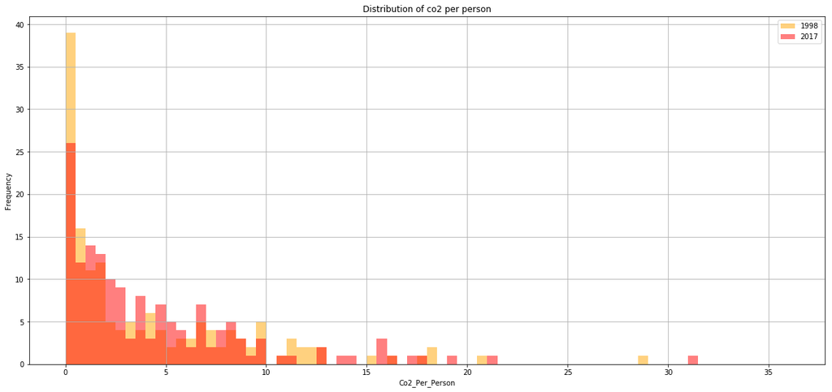

```python
#Build the histogram of co2 per person for year 1998 and 2017

HistogramIt(df=full_data_cleaned,var='co2_per_person',yearx=['1998','2017'],color=['orange','red'])
```

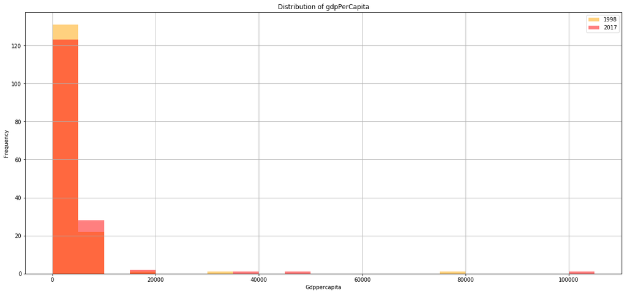

```python
#Build the histogram of GDP per capita for year 1998 and 2017
HistogramIt(df=full_data_cleaned,var='gdpPerCapita',bin_interval=5000,color=['orange','red'],yearx=['1998','2017'])
```

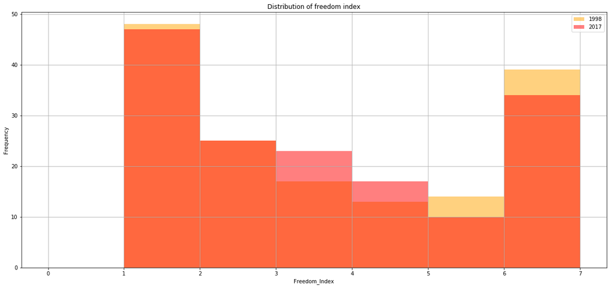

```python
#Build the histogram of freedom index for year 1998 and 2017

HistogramIt(df=full_data_cleaned,var='freedom_index',bin_interval=1,color=['orange','red'],yearx=['1998','2017'])
```

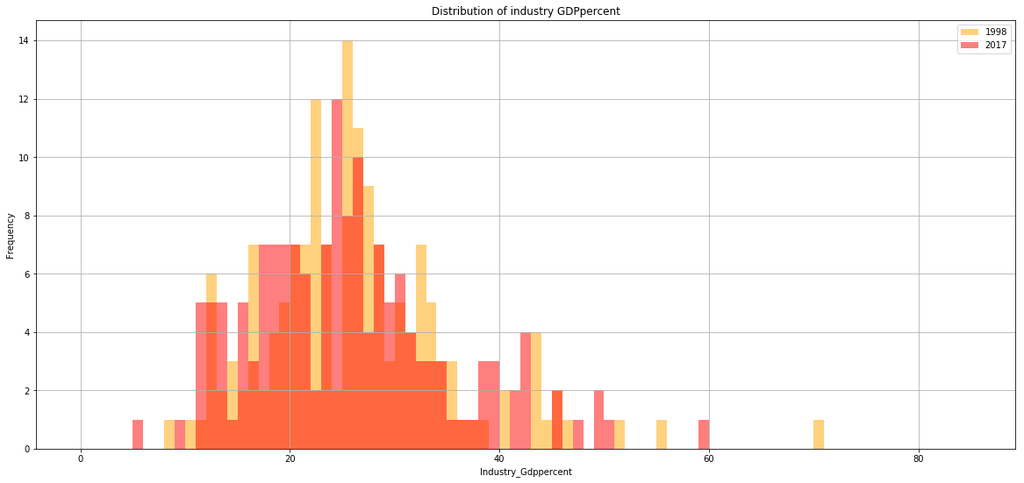

```python
#Build the histogram for the percentage of industry in GDP for year 1998 and 2017

HistogramIt(df=full_data_cleaned,var='industry_GDPpercent',bin_interval=1,color=['orange','red'],yearx=['1998','2017'])
```

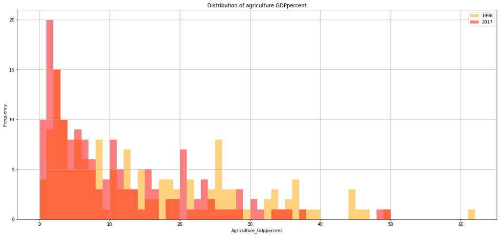

```python
#Build the histogram for the percentage of agriculture in GDP for year 1998 and 2017

HistogramIt(df=full_data_cleaned,var='agriculture_GDPpercent',bin_interval=1,color=['orange','red'],yearx=['1998','2017'])
```

> In order to add more perspective to the indexes, we could do some aggregation for each index across the years. Also, continent information is added here to add more perspective to the trends.

```python
#Yearly data
yearly_data = full_data_cleaned.select_dtypes('number').groupby('year').mean()

#Yearly data by continent

continent_yearly_data = full_data_cleaned[list(full_data_cleaned.select_dtypes('number').columns) + ['Continent']].groupby(['year','Continent']).mean()
```

```python
continent_yearly_data.head()
```

| year | Continent | co2_per_person | gdpPerCapita | freedom_index | industry_GDPpercent | agriculture_GDPpercent |
| --- | --- | --- | --- | --- | --- | --- |
| 1998 | Africa | 0.864386 | 1484.902381 | 4.666667 | 23.966667 | 25.202619 |
|  | Asia | 4.970100 | 3198.417143 | 4.771429 | 32.617143 | 16.506600 |
|  | Europe | 7.583154 | 3961.787179 | 1.769231 | 26.256410 | 7.052282 |
|  | North America | 4.433095 | 3600.752381 | 2.142857 | 23.561905 | 8.880000 |
|  | Oceania | 3.974125 | 2220.200000 | 2.000000 | 17.668750 | 15.033750 |

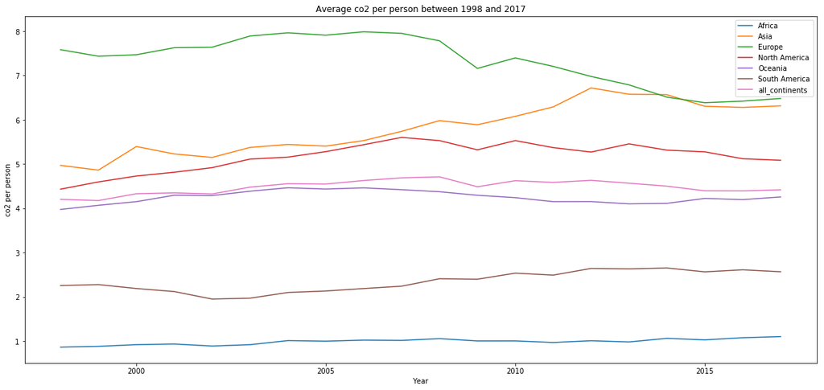

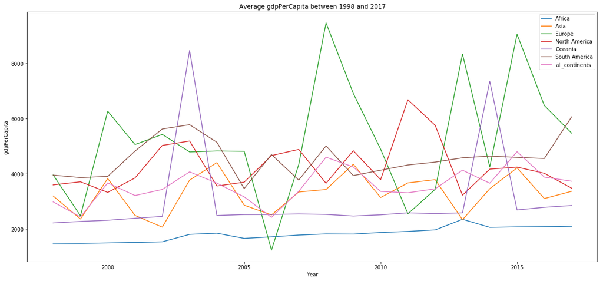

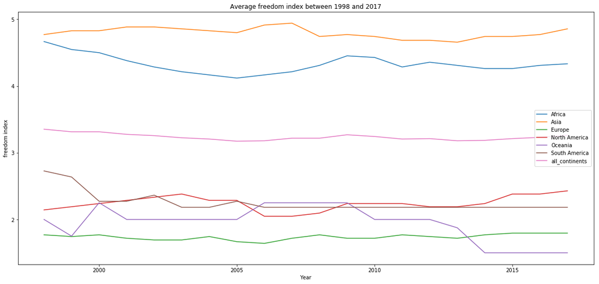

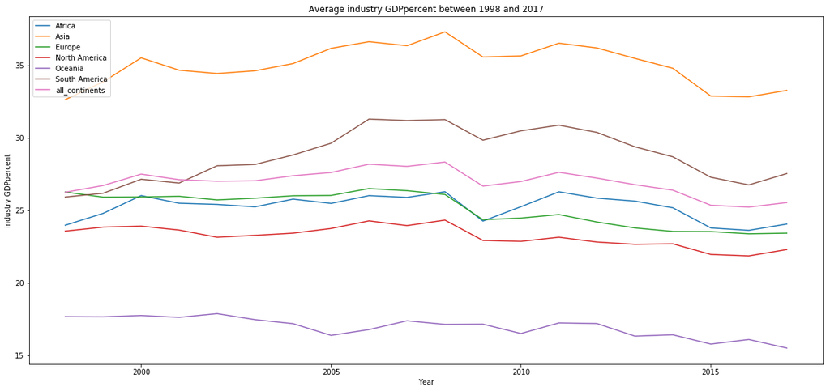

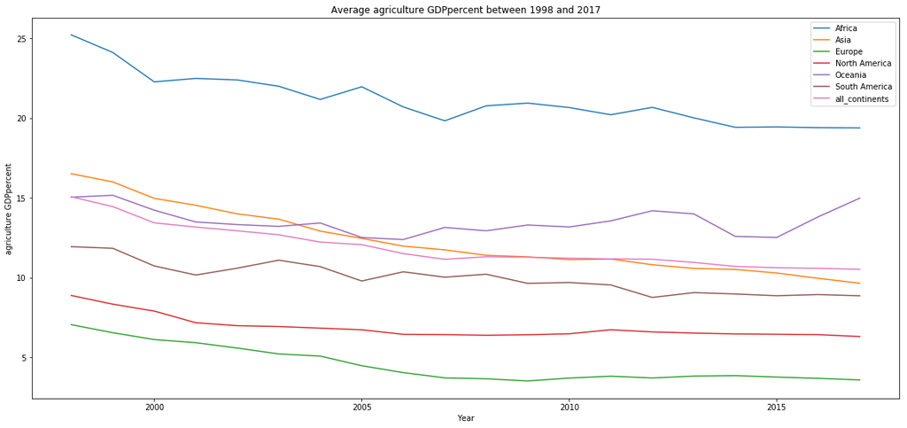

```python
#Plot the data
for col in continent_yearly_data:
    ax=continent_yearly_data[col].unstack('Continent').join(yearly_data[col].rename('all_continents')).plot(figsize = [20,9])
#integer tick labels only
    ax.locator_params(integer=True)

    plt.xlabel('Year')

    plt.ylabel(col.replace('_',' '))

    plt.title('Average '+ col.replace('_',' ') + ' between 1998 and 2017')
```

**Trend in average GDP per capita for 156 countries between 1998 and 2017**

There are a lot of fluctuations in the average GDP per capita among 156 countries. This fluctuation can be observed in all continents except for Africa. Interestingly, average GDP per capita in Asia is the closest to average GDP per capita in 156 countries.

Through the chart, we can see that some continents hit the highs and lows differently throughout the years.

Africa is stable with some steady improvements over the year.

Oceania is also stable with only two high hits in 2003 and 2014.

North America, South America and Europe in general has higher average GDP per capita over the years, as compared to the average GDP per capita in 156 countries, except for a few low-years.

**Trend in average freedom index for 156 countries between 1998 and 2017**

Freedom index development over the years on average for 156 countries does not seem to have much fluctuation. Looking continent-wise, Oceania's freedom index seems to have dropped since 2014. The visualization of the freedom index, especially in the context of continent-wise and comparing with average freedom index in 156 countries, is quite interesting.Average freedom index in Asia tops the chart over the years, and next to Asia is Africa.

### Correlation between the indexes

> Scatter plot is used to explore the correlation between CO2 emission per person and other indexes together with level. Economic level is defined based on the percentile of GDP per capita in a year. Since this economic level is more accurately evaluated on a yearly level, we would look at 2 slices of the data in 1998 and in 2017 to explore the correlations.

The green dots indicate the underdeveloped countries (25th percentile GDP per capita).

The yellow dots indicate the developing countries (50th percentile GDP per capita).

The red dots indicate the developed countries (75th percentile GDP per capita).

The purple dots indicate the very developed countries.

```python
#Looking at the statistics of GDP per capita in 1998 for example
full_data_cleaned.query('year == 1998')['gdpPerCapita'].describe()
```

```
count      156.000000
mean      2985.189744
std       6946.145521
min         10.600000
25%        291.500000
50%       1360.000000
75%       3732.500000
max      77000.000000
Name: gdpPerCapita, dtype: float64
```

```python
GDP_bucket = ['underdeveloped countries',
 'developing countries',
 'developed countries',
 'very developed countries']

#Generate economic level in 1998

full_data_cleaned['economic_level_1998']= pd.qcut(full_data_cleaned.query('year == 1998')['gdpPerCapita'],q=4,labels = GDP_bucket)
```

```python
#Generate economic level in 2017

full_data_cleaned['economic_level_2017']= pd.qcut(full_data_cleaned.query('year == 2017')['gdpPerCapita'],q=4,labels = GDP_bucket)
```

```python
full_data_cleaned.query('year == 1998 or year == 2017').head()
```

|  | country | year | co2_per_person | gdpPerCapita | freedom_index | industry_GDPpercent | agriculture_GDPpercent | Continent | Country | economic_level_1998 | economic_level_2017 |
| --- | --- | --- | --- | --- | --- | --- | --- | --- | --- | --- | --- |
| 0 | Albania | 1998 | 0.563 | 1600.0 | 4.0 | 15.3 | 28.80 | Europe | Albania | developed countries | NaN |
| 19 | Albania | 2017 | 1.610 | 4250.0 | 3.0 | 20.4 | 19.00 | Europe | Albania | NaN | developed countries |
| 20 | Angola | 1998 | 0.474 | 2490.0 | 6.0 | 55.2 | 12.90 | Africa | Angola | developed countries | NaN |
| 39 | Angola | 2017 | 1.140 | 3790.0 | 6.0 | 42.2 | 10.00 | Africa | Angola | NaN | developed countries |
| 40 | Antigua and Barbuda | 1998 | 4.360 | 13.3 | 4.0 | 12.7 | 1.67 | North America | Antigua and Barbuda | underdeveloped countries | NaN |

```python
#We cam use the scatter plot to explore if there is a pattern between CO2 ermission per person and other variables


#create function to return relative size for each country data based on GDP
def GDPsizeit(year,ecolevel):
    '''
    input:
    year: the year that we want to retrieve data from for the GDP per capita
    ecolevel: the economic level that we want to retrieve data from for the GDP per capita

    output:
    a list of the GDP per capita values as filtered in input divided by 10 to adjust for the marker size in scatter plot
    '''


    return full_data_cleaned.query(f'year=={year} and ' + 'economic_level_'+year+ '=="'+ecolevel +'"')['gdpPerCapita']/100
```

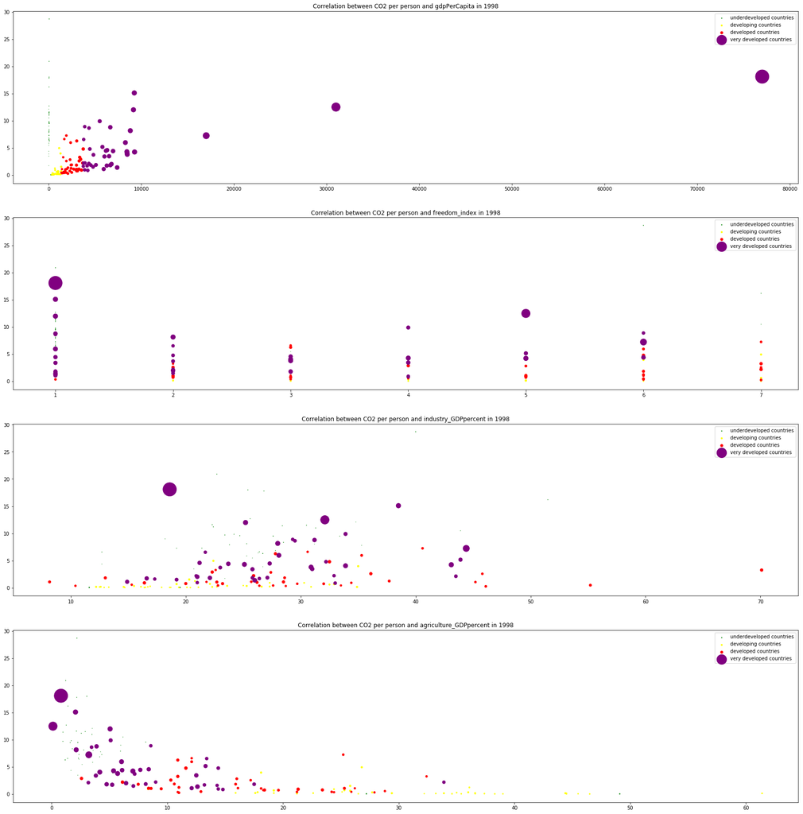

```python
#in 1998

#create subplots between CO2 and other variables

fig,ax = plt.subplots(4,figsize=(29,30))

#Create color bucket

color_bucket = ['green','yellow','red','purple']

for indcol, col in enumerate(list(full_data_cleaned.columns)[3:7]):

    for indbucket, bucket in enumerate(GDP_bucket):
        ax[indcol].scatter(col,'co2_per_person',data=full_data_cleaned.query('year==1998 and economic_level_1998=="'+bucket+'"'),s=GDPsizeit('1998',bucket),color=color_bucket[indbucket],label=bucket)
        ax[indcol].title.set_text(f'Correlation between CO2 per person and {col} in 1998')
        ax[indcol].legend()

plt.show()
```

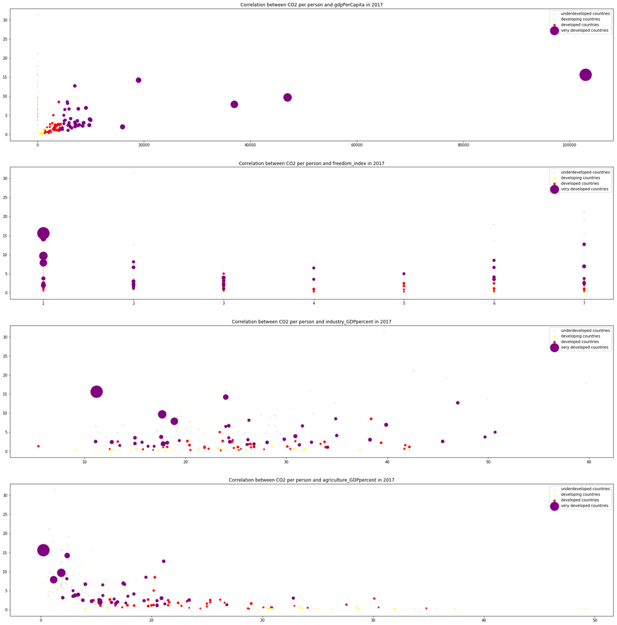

```python
#in 2017


#create subplots between CO2 and other variables

fig,ax = plt.subplots(4,figsize=(29,30))

#Create color bucket

for indcol, col in enumerate(list(full_data_cleaned.columns)[3:7]):

    for indbucket, bucket in enumerate(GDP_bucket):
        ax[indcol].scatter(col,'co2_per_person',data=full_data_cleaned.query('year==2017 and economic_level_2017=="'+bucket+'"'),s=GDPsizeit('2017',bucket),color=color_bucket[indbucket],label=bucket)
        ax[indcol].title.set_text(f'Correlation between CO2 per person and {col} in 2017')
        ax[indcol].legend()

plt.show()
```

## Conclusions

**Trends**

In our analysis for 156 countries between 1998 and 2017:

> There are a lot of fluctuations in the average GDP per capita among 156 countries. This fluctuation can be observed in all continents except for Africa. Interestingly, average GDP per capita in Asia is the closest to average GDP per capita in 156 countries between the years 1998 and 2017.

> The freedom index does not have much fluctuation on average for 156 countries over the years. We might need a few more indexes related to political rights and freedom to add more insights to the freedom index from Gapminder. The question here is why continents with more democratic societies have very low rating in freedom indexes. How the samples are collected and how the ratings are designed also affect the result significantly.

**Correlation**

We might also need a wider time span (repeated findings in multiple years) to confirm the correlations between CO2 emission per person and other indexes. More efforts can also look into confirming if agriculture percentage in GDP and industry percentage in GDP do not have correlation with CO2 emission per capita. We can also try using other indexes to measure CO2, for example, only total CO2 emission or CO2 emission per USD earned in GDP.

### Limitations

Several limitations can be summarized below:

> The range of time in scope for analysis. We need a wider time scope to confirm and enrich the findings.

> The number of countries included in the analysis are limited to 156 countries with available data in the given years.

> There are multiple missing values in broadband subscribers per 100 people, resulting in dropping the variable completely from the dataset. Also, missing values in other variables also reduce the sample size for analysis.

> The correlation analysis is done in 2 slices of yearly data. There should be confirmed correlations in more years.

> Freedom index used in the analysis might be subjected to the ratings and survey design. The index should be compared against other similarly measured indexes in the same category.

> No statistical inference was performed in this analysis. This limits any possible generalization conclusion based on the sample data.

```python
from subprocess import call
call(['python', '-m', 'nbconvert', 'Investigate_a_Dataset.ipynb'])
```